# Cálculo de Prima de Seguro de Producción de Aguacate usando GLM

Canedo B, Braulio y Rueda V, M Rocio

2025-03-17

# 1. Introducción

A lo largo de los años se ha visualizado el creciente impacto de la agricultura en México, contando con una aportación mayor en relación con el sector pesquero, pecuario y acuicola.

Esta actividad otorga diversos beneficios al proveer alimentos, materias primas, mano de obra, empleos y recursos económicos. Sin embargo, la posición geográfica, y caracteristicas geológicas, hidrológicas y meteorológicas pueden desencadenar impactos negativos en este sector, tales como la pérdida de la producción, aumento en los precios y afectaciones en el bienestar social. De manera especifica, la producción de aguacate a nivel nacional se ha visto afectada por cambios climáticos y temporadas prolongadas de sequia, lluvia y plagas. Además, las variables exógenas como la oferta, demanda, problemáticas sociales y politicas e industrialización han provocado vulnerabilidad en miles de productores mexicanos.

De acuerdo con datos del Banco de México, durante el 2021 el valor de las exportaciones de aguacate ascendió a 3 mil 85 millones de dólares, un incremento de 14.2% en comparación con los 2 mil 699 millones reportados en 2020. De esta forma, el aguacate se ubicó como el tercer producto agroindustrial que más vende México al mundo, sólo por debajo de la cerveza (Carbajal, 2022).

Por esta razón, se considera importante la implementación de una estrategia como gestión de riesgo para la cosecha, control de plagas y protección ante factores naturales. Dicha estrategia se basa en una alternativa asequible a través de la identificación de la naturaleza del riesgo y el tipo de seguro más conveniente.

El seguro agricola tiene como objetivo minimizar riesgos en la producción, promover la creación y aumento de capital y garantizar un mecanismo de compensación en caso de la ocurrencia de siniestros.

Los resultados que se obtengan de esta propuesta de seguro pueden ser utilizados como base para que el sector asegurador tenga la oportunidad de ofrecer un servicio a favor de la protección de la producción de aguacate, de manera accesible a las capacidades económicas de los agricultores, considerando la relación costo-beneficio para las familias y empresas.

# 2. Objetivo

Calcular la Prima Pura de Riesgo que cubra las pérdidas durante la producción del Aguacate en México, usando datos entre 2003 y 2022.

1. Ajustar los riesgos asociados a la producción de aguacate en México durante el periodo 2003-2023 mediante un Modelo Lineal Generalizado (GLM).
2. Segmentar los datos por zonas de riesgo, considerando la influencia de operaciones delictivas relacionadas con el narcotráfico.
3. Realizar un análisis de estrés sobre el cálculo de la Prima Pura de Riesgo mediante simulaciones, con el objetivo de evaluar su sensibilidad ante escenarios adversos.

> Para la visualización del código en Github usar la siguiente liga: https://github.com/brau126/develop_data_science/blob/main/Academic/Re-Sampling/Aguacate_GLM_final.Rmd

# 3. Literatura (Marco teórico)

## 3.1. Contexto histórico

El árbol de aguacate es originario de Mesoamérica, con sus raices en el centro de México y en algunas regiones montañosas de Guatemala. La evidencia más antigua del uso del aguacate como alimento se encuentra en la cueva de Coxcatlán, ubicada en Tehuacán, Puebla.

A nivel mundial, más de 60 paises producen aguacate, y existen más de 500 variedades de esta fruta. En México, se destacan tres variedades principales: el aguacate Hass, el Criollo y el Fuerte. (Gobierno de México, 2016)

En el 2022, Michoacán fue responsable del 73% de la producción total de aguacates en México, destacando los municipios de Tancitaro, Uruapan y Tacámbaro como pilares de la industria. Sin embargo, el crecimiento de los cultivos de aguacate no ha generado beneficios equitativos para todos los involucrados. En múltiples ocasiones, este fenómeno ha estado impulsado por acuerdos entre el crimen organizado y autoridades locales.

Según el estudio realizado por Le Cour Grandmaison y Frissard Martinez (2024), las regiones con altos niveles de inseguridad tienden a convertir la violencia en una herramienta politica y económica. En este contexto, la expansión del mercado de aguacates se ha visto favorecida por la colaboración entre autoridades, élites locales y grupos violentos.

La industria del aguacate también ha dejado un impacto significativo en el medio ambiente. En Michoacán, el aumento de la demanda provocó la expansión de tierras dedicadas a su cultivo, lo que resultó en deforestación y degradación del suelo, el agua y la biodiversidad. Esta expansión agricola, impulsada por la violencia ejercida por diversos actores, transformó bosques y áreas protegidas en zonas agricolas. De acuerdo con fuentes gubernamentales, el 80% de las huertas de aguacate en Michoacán fueron establecidas ilegalmente, comenzando con el uso no autorizado de tierras que posteriormente se convirtieron en parcelas legales gracias a la complicidad de las autoridades.

## 3.2. Manual de Seguros de Cultivos

Este manual, desarrollado por (Evans & Ballen, 2017) tiene como objetivo informar a los productores sobre cómo se puede mitigar el riesgo de la producción de aguacate a través de los programas federales de Estados Unidos disponibles relacionados a seguros agricolas.

A través de las tres secciones que contiene, se provee información acerca de:

1. Criterios de elegibilidad del seguro (en Estados Unidos)
- Historial de producción de 4 a 10 años de rendimientos históricos de la unidad asegurada para determinar la garantia y la tasa de prima.
- El monto de la prima depende del nivel de cobertura deseado (generalmente del 50 al 75%) y el porcentaje de la elección de precio (fijados en algunas politicas)
- Los deducibles del seguro de cosechas varian de 25 a 50% en incrementos del 5%
2. Obtención de un estimado del seguro utilizando la herramienta de United States Department of Agriculture, Risk Management Agency
3. Cálculo de una indemnización a través de Excel
- Las indemnizaciones (pagos de seguros) se reciben sólo si el rendimiento real es inferior a la garantia de rendimiento. Si el rendimiento real es igual a la garantia de rendimiento, no hay pago de indemnización al productor asegurado.

## 3.3. Modelo Lineal Generalizado

El modelo de regresión lineal simple se basa en los siguientes tres supuestos fundamentales:

- Linealidad en los parámetros.
- Término de error distribuido de forma normal.
- Varianza homocedástica del error.

El principal problema del modelo de regresión simple es que estos supuestos son a menudo infringidos. Tal es el caso de la varianza, que suele aumentar con la media, debido a que se espera que las pólizas con costos siniestrales más altos tengan también mayores varianzas en el número de siniestros.

Es aqui donde aparece el modelo lineal generalizado a partir de la necesidad de aportar un modelo que solucione la no linealidad en los parámetros y la no normalidad y heterocedasticidad del error.

### 3.3.1. Componentes del MLG

- Componente aleatorio En el modelo lineal generalizado, la variable respuesta es una serie de datos independientes que siguen una distribución de la familia exponencial (gamma, lognormal, Pareto…). Esta trata de modelizar de una forma no-normal la distribución del término de error del modelo.
- Componente sistemático Este componente es una combinación lineal de las variables explicativas En el trabajo realizado por Villarino G. (2017) se estudiaron las diferentes técnicas estadisticas para el ajuste de distribuciones de la familia exponencial, además de comparar los valores en riesgo y de la cola en riesgo, para el análisis de riesgo de la tarificación de seguros de auto

Posteriormente, se estimó el GLM gamma con link logaritmica propuesto por Jong y Heller y comparándolos con un GLM log-normal mediante gráficos de diagnosis de los residuos.

Esto se hizo con la finalidad de mejorar el nuevo modelo mediante la eliminación de variables no relevantes, con el din de generar interpretaciones para una póliza de una persona con caracteristicas especificas.

## 3.4. Modelo Lineal Generalizado Mixto

Con base en el articulo realizado por Bandera F. & Pérez P. (2018), los datos de investigaciones agricolas no siempre satisfacen las premisas de los modelos lineales generales; por ello es que existen los Modelos Lineales Generalizados Mixtos, que proporcionan una via de análisis para aquellos datos correlacionados y cuyas variables evaluadas sean distribuidas por parte de la familia exponencial.

Los procedimientos de estimación de los GLMMs posibilitan reducir los sesgos cuando los datos están incompletos, desbalanceados o ajustar datos dispersos y permiten además modelar la estructura de los errores en datos provenientes de mediciones longitudinales.

Los modelos lineales mixtos son una generalización de modelos lineales generales y se emplean cuando:

- Los efectos son aleatorios: donde el conjunto de valores de una variable de predictor categórico se ven no como el conjunto completo, sino como una muestra aleatoria de todos los valores
- Efectos jerárquicos: donde se miden variables predictoras en más de un nivel.
- Estimación por máxima verosimilitud.

El algoritmo de los modelos mixtos permite calcular el mejor estimador lineal insesgado (red, Best Linear Unbiased Estimate) de efectos fijos y el mejor predictor lineal insesgado (BLUP, Best Linear Unbiased Predictor) de los efectos aleatorios. El BLUP representa la esperanza condicional de los efectos aleatorios dada a los datos observados, y es también un estimador Bayesiano. El BLUP de una combinación lineal de efectos fijos y aleatorios, es la combinación lineal de los red de efectos fijos y los BLUP de efectos aleatorios.

# 4. Análisis exploratorio

## 4.1. Limpieza y Organización Previa

Es importante visualizar si la base de datos de df_deaths tiene diferenciado a los datos de Distrito Federal y Ciudad de México como dos estados diferentes, primero es necesario homogenizar.

```r
# Observamos los valores únicos de los estados
unique(df_deaths$adm_1)
```

```
##  [1] "Distrito Federal"          "Jalisco state"
##  [3] "Morelos state"             NA
##  [5] "Sinaloa state"             "Guerrero state"
##  [7] "Chiapas state"             "Oaxaca state"
##  [9] "Mexico state"              "Veracruz state"
## [11] "Chihuahua state"           "Tamaulipas state"
## [13] "Sonora state"              "Nuevo Leon state"
## [15] "Quintana Roo state"        "Baja California state"
## [17] "Michoacan state"           "Durango state"
## [19] "Tabasco state"             "Guanajuato state"
## [21] "Coahuila state"            "Hidalgo state"
## [23] "Yucatan state"             "Zacatecas state"
## [25] "Nayarit state"             "Colima state"
## [27] "San Luis Potosi state"     "Baja California Sur state"
## [29] "Puebla state"              "Ciudad de Mexico"
## [31] "Aguascalientes state"      "Queretaro state"
## [33] "Tlaxcala state"
```

Dado que no solo no se tiene homogenizado se modifican los datos no solo para homogeinizar, pero también para retirar la palabra state de cada de los estados, aunado a ello se retira la palabra state de cada uno de los valores.

```r
# Intercambiamos los valores de Distrito Federal
df_deaths <- df_deaths %>%
  dplyr::mutate(adm_1 = gsub(" state", "", adm_1)) %>% # la función gsub funciona como un buscar y reemplazar
  dplyr::mutate(adm_1 = dplyr::recode(adm_1,
                        "Distrito Federal" = "Ciudad de Mexico")
         )
```

```r
# Para la tabla de Violencia se añade la columna del total de muertes
df_deaths <- df_deaths %>%
  mutate(df_deaths, total_muertes = deaths_a + deaths_b+deaths_civilians + deaths_unknown)

# Columna de perdida/merma entre siembra y cosecha
df_aguacate <- df_aguacate %>%
  mutate(df_aguacate, perdida_siembra_cosecha = Sembrada - Cosechada)
```

## 4.2. Descripción de Columnas

```r
# Crear la tabla descriptiva
descripcion <- df_aguacate %>%
  summarise(across(where(is.numeric), list(
    Observaciones = ~ sum(!is.na(.)),
    Media = ~ mean(., na.rm = TRUE),
    Mediana = ~ median(., na.rm = TRUE),
    Varianza = ~ var(., na.rm = TRUE),
    Minimo = ~ min(., na.rm = TRUE),
    Maximo = ~ max(., na.rm = TRUE),
    Curtosis = ~ kurtosis(., na.rm = TRUE)
  ), .names = "{col}_{fn}")) %>%
  pivot_longer(everything(), names_to = c("Variable", ".value"), names_sep = "_")
descripcion
```

```
## # A tibble: 23 × 9
##    Variable       Observaciones   Media Mediana Varianza  Minimo Maximo Curtosis
##    <chr>                  <int>   <dbl>   <dbl>    <dbl>   <dbl>  <dbl>    <dbl>
##  1 Anio                   12060  2.01e3    2014  3.27e+1 2.00e+3 2.02e3     1.85
##  2 Idestado               12060  1.74e1      16  3.86e+1 1   e+0 3.2 e1     3.41
##  3 Idddr                  12060  9.17e1      91  1.60e+3 1   e+0 1.9 e2     3.42
##  4 Idcader                12060  2.75e0       2  3.06e+0 1   e+0 1   e1     4.55
##  5 Idmunicipio            12060  1.05e2      59  1.70e+4 1   e+0 5.66e2     6.21
##  6 Idciclo                12060  3   e0       3  0       3   e+0 3   e0   NaN
##  7 Idmodalidad            12060  1.51e0       2  2.50e-1 1   e+0 2   e0     1.00
##  8 Idunidadmedida         12060  2.00e5  200201  0       2.00e+5 2.00e5   NaN
##  9 Idcultivo              12060  5.06e6 5060000  0       5.06e+6 5.06e6   NaN
## 10 Sembrada               12060  2.81e2      18  1.46e+6 6   e-2 2.10e4    86.3
## # ℹ 13 more rows
## # ℹ 1 more variable: siembra <dbl>
```

```r
# Calcular la matriz de correlación
matriz_cor <- cor(df_aguacate %>%
                    dplyr::select(Anio,Idestado,Idmunicipio,Idciclo,Idmodalidad,Idunidadmedida,
                                Sembrada,Cosechada,Siniestrada,Volumenproduccion,Rendimiento,
                                Precio,Valorproduccion,perdida_siembra_cosecha))
```

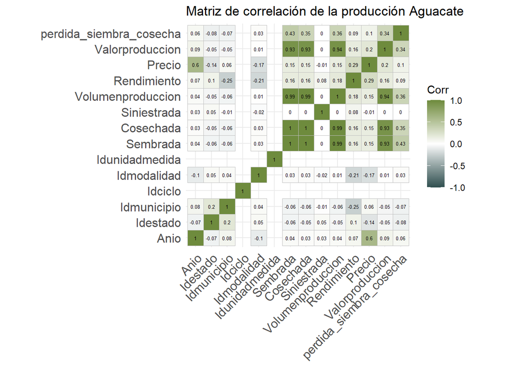

```r
# Crear el gráfico de correlación
ggcorrplot(matriz_cor,  title = "Matriz de correlación de la producción Aguacate",
           lab = TRUE, lab_size = 1.75,
           colors = c("darkslategray","white","darkolivegreen4"))
```

## 4.4. Producción y Pérdidas de Aguacate

Guiándose de los valores de Volumen de Producción de la SIAP de 2003 a 2022 se observa una clara tendencia a la alza de la producción de Aguacate. Con un crecimiento lineal controlado.

[figure not shown]

Tomando en cuenta la alza de producción y la demanda del aguacate es importante comprender y corroborar la distribución de su producción a lo largo de la República Mexicana, pues según Le Cour Grandmaison & Frissard Martinez (2024) utilizando datos dde la SIAP Michoacán es el estado que mas concentró le producción de aguacate, abarcando un 73% de la cantidad de producción nacional.

[figure not shown]

Evidencia que Michoacan a lo largo de 19 años a concentrado un 80% del Volumen de Producción.

```r
sum(df_aguacate %>%
      filter(Nomestado == "Michoacan") %>% # primero hay que filtrar
      dplyr::select(Volumenproduccion)) / sum(df_aguacate$Volumenproduccion)
```

```
## [1] 0.8035173
```

Por ello mismo también influye en que sea el estado en el cual se han presentado mayor cantidad de Pérdidas de Toneladas con respecto a las toneladas de Aguacate Sembrado y lo Cosechado. A pesar de la diferencia de producción las pérdidas si presentan mayor dispersión.

[figure not shown]

Habiendo presencias de perdidas presentes en Jalisco, se puede suponer que está relacionado con la presencia del cartel Jalisco nueva generación y en todo caso ser posible visualizar una correlación entre las perdidas de siembra y presencia se carteles. Viendo solo la distribución de la cantidad de conflictos armados de carteles por cada estado, a primera vista no hay una presencia de alguna correlación.

No se debe dejar de lado visualizar el comportamiento de las pérdidas a lo largo de los años asi como la distribución de estados en cada uno de ls años.

[figure not shown]

Con punto máximo de pérdias en 2017 el cual posteriormente se analiza la relación que tiene con situaciones de relevancia nacional que pudieron haber inlfuido en este comportamiento. De igual se identifica un pico en 2021 tras 3 años de tendencia a la baja, también puede ser relacionable a sucesos de talla nacional que se supone pudieron haber sido un factor.

## 4.5. Presencia de Conflictos de Cárteles

La incetidumbre y los factores externos a los productores repercuten en la producción de aguacate, desde la inseguridad y presión que pueden ejercer grupos delictivos asi como el cobro por poder hacer uso del suelo. Deacuerdo a datos de la Universidad UPSSALA se recuperan datos de conflictos armados y violencia en México desde 1980. Con esta información y tomando en cuenta el impacto de la inseguridad es importante reconocer los estados más impactados por los grupos de crimen organizado, observando el impacto de muertes totales por estados.

[figure not shown]

Con Michoacan, el mayor productor, dentro de los primeros 5 con mayor número de muertes por conflictos entre 2003 y 2023 y con un promedio de 7.39 muertes anuales. A pesar de ser más bajo de lo esperado es solo parte de la relación de riesgo y pecencia de cirmen organizado, pues deacuerdo a Le Cour (2024) los conflictos solo son una parte de las consecuencias del crimen organizado, pues también se ven las consecuencias en personas desaparecidas, cobro de derecho de piso, extorsiones, secuestros, entre otros.

A pesar de ello es importante resaltar impacto directo que tienen la presencia de agresiones directamente hacia civiles en todo el pais.

[figure not shown]

Siendo Tamaulipas, Chihuahua y Sinaloa los estados con mayor cantidad de agresiones dirigidas a civiles, seguido de Jalisco el segundo estado con más pérdidas de siembra de aguacate.

[figure not shown]

## 4.6. Distribución empirica de las toneladas de pérdida

Una vez comprendido las carácteristicas de la producción de aguacate y los datos de violencia y cárteles revisamos que sean ambas crecientes en el tiempo. Mas cabe resaltar que la violencia tiene tendencia afectada por factores externos por lo que su crecimeinto no es constante

[figure not shown]

Tomando eso en cuenta se compara el estado con mayor producción de aguacate y superpone su producción y la violencia.

[figure not shown]

Se visualizan tres momentos importantes donde hay cambios abruptos en la serie:

- 2009
  - Guerra abierta de cárteles en Ciudad Juárez, el gobierno de Calderón envia 5mil solados adicionales
  - Incendio de guarderia ABC, lamentable suceso el cual se sospecha fue cortina de humo
  - Asesinato de lider del cártel de los Beltran-Leyva
- 2017
  - El Chapo es aprehendido a finales del 2016
- 2021
  - Cienfuegos es liberado tras ser acusado por el gobierno Estadounidense de colusión con cárteles
  - Caro Quintero es liberado tras falta de evidencia en su contra

Aunque la relación no es evidente con el volumen de producción, mas que una tendencia a la alza, en cambio comparando con las toneladas de pérdidas se percibe el impacto

[figure not shown]

Teniendo en cuenta que el cálculo de prima será realizado por medio de GLM, es importante entender revisar el ajuste de los datos hacia alguna distribución para su mejor comprensión al momento de realizar el análisis de regresión. EL ajuste se realiza principalmente en la nueva variable creada “Perdida_siembra_cosecha”.

Primero es necesario entender las genralidades de la Pérdida, para ello primero se resumen las pérdidas en una tabla de frecuencia por intervalos, pues graficar sin ello complica una interpretación adecuada.

```r
# Crear intervalos
n_intervalos = 50
ancho_intervalo = max(df_aguacate$perdida_siembra_cosecha) / n_intervalos

# Creamos tabla de frecuencia
tabla_frec_syc <- df_aguacate %>%
  filter(perdida_siembra_cosecha != 0) %>%
  dplyr::select(perdida_siembra_cosecha) %>%
  dplyr::mutate(intervalo_perd_syc = cut_width(perdida_siembra_cosecha,
                                   width = ancho_intervalo)) %>%
  group_by(intervalo_perd_syc) %>%
  summarize(frec_perdida = n()) %>%
  complete(intervalo_perd_syc, fill = list(frec = 0))

tabla_frec_syc
```

```
## # A tibble: 51 × 2
##    intervalo_perd_syc frec_perdida
##    <fct>                     <int>
##  1 [-29.3,29.3]               3920
##  2 (29.3,87.9]                 864
##  3 (87.9,146]                  292
##  4 (146,205]                   159
##  5 (205,264]                    95
##  6 (264,322]                    68
##  7 (322,381]                    37
##  8 (381,440]                    28
##  9 (440,498]                    22
## 10 (498,557]                    13
## # ℹ 41 more rows
```

Se grafican las frecuencias de los intervalos, para visualizar la distribución empirica de las pérdidas, omitiendo todos los valores de cero que indiquen que no hay pérdida.

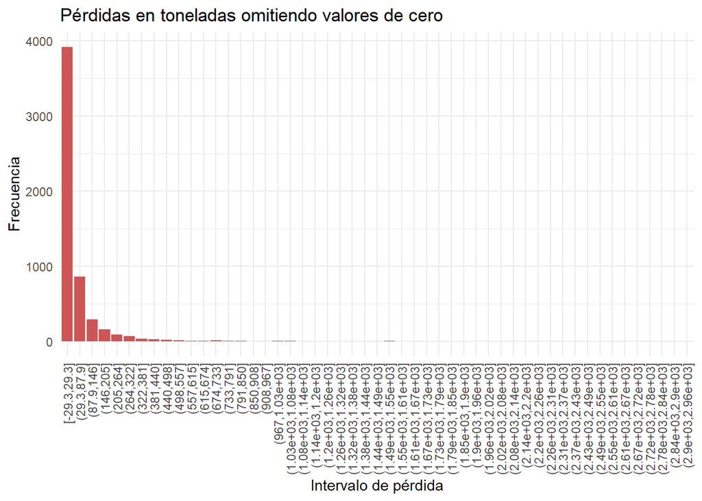

```r
# Histograma de datos
ggplot(tabla_frec_syc, aes(x=intervalo_perd_syc, y = frec_perdida))+
  geom_col(fill = "indianred3") +
#  geom_histogram(aes(y = after_stat(frec_perdida)), binwidth = 1, fill="purple", color="black") +
  labs(title = "Pérdidas en toneladas omitiendo valores de cero",
       x= "Intervalo de pérdida",
       y= "Frecuencia") +
  guides(x = guide_axis(angle = 90)) +
  theme_minimal()
```

De manera visual y como primera conclusión se puede suponer que las pérdidas se distriuyen Exponencial, con varios valores extremos. Es necesario comprobar esta hipótesis con purebas estadisticas. Mas antes es necesario buscar la forma de evitar valores extremos para evitar la necesidad de censura.

Se opta por no usar los valores absolutos, en cambio utilizar un indice de pérdida donde cada una de las pérdidas se divide entre el promedio de cosecha
$$Indice = \frac{Sembrada
- Cosechada}{mean(Cosechada)}$$
, la mediana no pues se ve sesgada.

```r
# Creamos primero
df_aguacate <- df_aguacate %>%
  dplyr::mutate(df_aguacate, indice_perdida_cys = perdida_siembra_cosecha/mean(Cosechada))

# Indice vs Absoluto
options(scipen = 999) # evitar notación cientifica
df_aguacate %>%
  dplyr::select(c(perdida_siembra_cosecha, indice_perdida_cys)) %>%
  dplyr::mutate(indice_perdida_cys = round(indice_perdida_cys, 4))
```

```
## # A tibble: 12,060 × 2
##    perdida_siembra_cosecha indice_perdida_cys
##                      <dbl>              <dbl>
##  1                    25.4             0.0995
##  2                     0               0
##  3                    28               0.110
##  4                     0               0
##  5                     0               0
##  6                     0               0
##  7                    44               0.173
##  8                     2.5             0.0098
##  9                     2.5             0.0098
## 10                     2               0.0079
## # ℹ 12,050 more rows
```

Se gráfica para observar la modificación del indice y ver su distribución empirica, se omiten valores de 0.

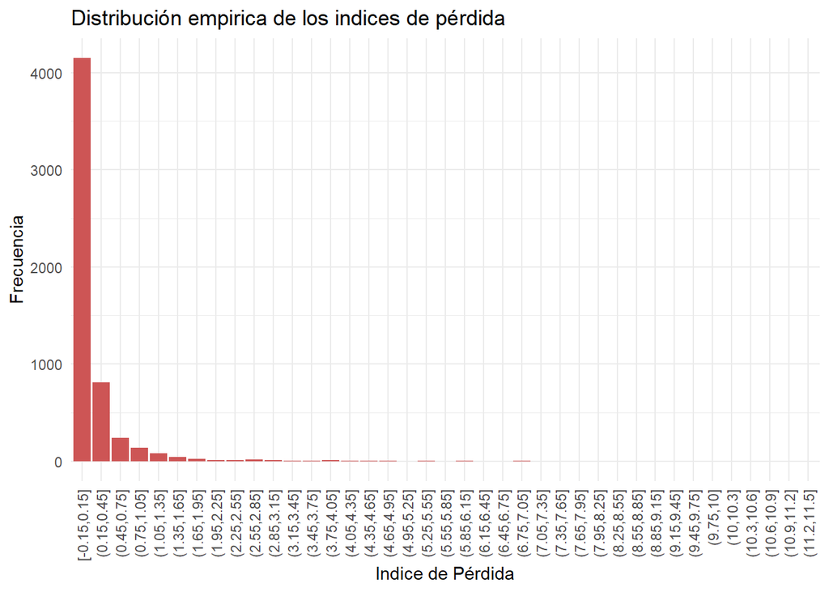

```r
# Crear intervalos
#n_intv_ind = 1/2
#ancho_intervalo_ind = max(df_aguacate$indice_perdida_cys) / n_intv_ind
ancho_intervalo_ind = 0.3

# Filtrar y crear nuevo data frame omitiendo los valores de 0
tabla_frec_indice_syc <- df_aguacate %>%
  filter(indice_perdida_cys != 0) %>%
  dplyr::select(indice_perdida_cys) %>%
  dplyr::mutate(intervalo_indice_syc = cut_width(indice_perdida_cys,
                                          width = ancho_intervalo_ind)) %>%
  group_by(intervalo_indice_syc) %>%
  summarize(frec_ind_perdida = n())  %>%
  complete(intervalo_indice_syc, fill = list(frec = 0))

# Graficamos histograma del indice de pérdida
ggplot(data = tabla_frec_indice_syc, aes(x = intervalo_indice_syc, y = frec_ind_perdida)) +
  geom_col(fill = "indianred3") +
  labs(title = "Distribución empirica de los indices de pérdida",
       y = "Frecuencia",
       x = "Indice de Pérdida")+
  guides(x = guide_axis(angle = 90)) +
  theme_minimal()
```

### 4.6.1 Ajuste a Distribución

```r
##  4.7. Ajuste de Distribución
# ---- AJUSTE LOG-NORMAL ----#
library(fitdistrplus)
library(nortest)

# Crear nuevo data frame omitiendo los valores NA
tabla_frec_2 <- tabla_frec_indice_syc$frec_ind_perdida
tabla_frec_indice_syc_2 <- tabla_frec_2[!is.na(tabla_frec_2)]

dislogn <- fitdist(tabla_frec_indice_syc_2, "lnorm", method = "mle")

summary(dislogn)
```

```
## Fitting of the distribution ' lnorm ' by maximum likelihood
## Parameters :
##         estimate Std. Error
## meanlog 2.351175  0.4203669
## sdlog   2.143459  0.2972440
## Loglikelihood:  -117.8459   AIC:  239.6918   BIC:  242.208
## Correlation matrix:
##         meanlog sdlog
## meanlog       1     0
## sdlog         0     1
```

```r
confint(dislogn)
```

```
##            2.5 %   97.5 %
## meanlog 1.527271 3.175079
## sdlog   1.560871 2.726046
```

```r
gofstat(dislogn)
```

```
## Goodness-of-fit statistics
##                              1-mle-lnorm
## Kolmogorov-Smirnov statistic   0.1388875
## Cramer-von Mises statistic     0.1229365
## Anderson-Darling statistic     0.8182161
##
## Goodness-of-fit criteria
##                                1-mle-lnorm
## Akaike's Information Criterion    239.6918
## Bayesian Information Criterion    242.2080
```

```r
mu<-dislogn$estimate[1]
sigmaln<-dislogn$estimate[2]

ks.test(tabla_frec_indice_syc_2,"plnorm", meanlog=mu, sdlog<-sigmaln)
```

```
##
##  Asymptotic one-sample Kolmogorov-Smirnov test
##
## data:  tabla_frec_indice_syc_2
## D = 0.13889, p-value = 0.6976
## alternative hypothesis: two-sided
```

```r
ad.test(plnorm(tabla_frec_indice_syc_2, meanlog=mu, sdlog<-sigmaln ))
```

```
##
##  Anderson-Darling normality test
##
## data:  plnorm(tabla_frec_indice_syc_2, meanlog = mu, sdlog <- sigmaln)
## A = 0.69173, p-value = 0.06248
```

```r
#--- AJUSTE PARETO ----#
fitpareto <- fitdist(tabla_frec_indice_syc_2, "pareto",
                     method = "mge")
summary(fitpareto)
```

```
## Fitting of the distribution ' pareto ' by maximum goodness-of-fit
## Parameters :
##        estimate
## shape 0.3411585
## scale 0.7688193
## Loglikelihood:  -112.2783   AIC:  228.5567   BIC:  231.0728
```

```r
fitpareto$estimate
```

```
##     shape     scale
## 0.3411585 0.7688193
```

```r
confint(fitpareto)
```

```
##       2.5 % 97.5 %
## shape    NA     NA
## scale    NA     NA
```

```r
gofstat(fitpareto)
```

```
## Goodness-of-fit statistics
##                              1-mge-pareto
## Kolmogorov-Smirnov statistic   0.14498348
## Cramer-von Mises statistic     0.08009694
## Anderson-Darling statistic     0.63692065
##
## Goodness-of-fit criteria
##                                1-mge-pareto
## Akaike's Information Criterion     228.5567
## Bayesian Information Criterion     231.0728
```

```r
alphap<-fitpareto$estimate[1]

thetap<-fitpareto$estimate[2]

ks.test(tabla_frec_indice_syc_2,"ppareto", shape=alphap, scale=thetap)
```

```
##
##  Asymptotic one-sample Kolmogorov-Smirnov test
##
## data:  tabla_frec_indice_syc_2
## D = 0.14498, p-value = 0.6452
## alternative hypothesis: two-sided
```

```r
ad.test(ppareto(tabla_frec_indice_syc_2,shape=alphap , scale=thetap))
```

```
##
##  Anderson-Darling normality test
##
## data:  ppareto(tabla_frec_indice_syc_2, shape = alphap, scale = thetap)
## A = 0.60641, p-value = 0.1031
```

```r
# --- AJUSTE EXPONENCIAL --- #

# Ajuste por método de momentos
fitexp <- fitdist(tabla_frec_indice_syc_2, "exp", method = "mme")

# Resumen del ajuste
summary(fitexp)
```

```
## Fitting of the distribution ' exp ' by matching moments
## Parameters :
##         estimate   Std. Error
## rate 0.004648668 0.0009116788
## Loglikelihood:  -165.6505   AIC:  333.3011   BIC:  334.5592
```

```r
# Estimación del parámetro
fitexp$estimate
```

```
##        rate
## 0.004648668
```

```r
rate_exp <- fitexp$estimate["rate"]

# Intervalos de confianza
confint(fitexp)
```

```
##           2.5 %      97.5 %
## rate 0.00286181 0.006435526
```

```r
# Estadísticos de Bondad de ajuste
gofstat(fitexp)
```

```
## Goodness-of-fit statistics
##                              1-mme-exp
## Kolmogorov-Smirnov statistic  0.655384
## Cramer-von Mises statistic    4.112355
## Anderson-Darling statistic   35.407767
##
## Goodness-of-fit criteria
##                                1-mme-exp
## Akaike's Information Criterion  333.3011
## Bayesian Information Criterion  334.5592
```

```r
# Prueba K-S
ks.test(tabla_frec_indice_syc_2, "pexp", rate = rate_exp)
```

```
##
##  Asymptotic one-sample Kolmogorov-Smirnov test
##
## data:  tabla_frec_indice_syc_2
## D = 0.65538, p-value = 0.0000000003989
## alternative hypothesis: two-sided
```

```r
# Prueba A-D
ad.test(pexp(tabla_frec_indice_syc_2, rate = rate_exp))
```

```
##
##  Anderson-Darling normality test
##
## data:  pexp(tabla_frec_indice_syc_2, rate = rate_exp)
## A = 4.5165, p-value = 0.00000000001509
```

```r
#--- AJUSTE GAMMA ----#
iniciales_gamma <- fitdist(tabla_frec_indice_syc_2, "gamma",
                     method = "mme")

ini_shape <- iniciales_gamma$estimate[1]
ini_rate <- iniciales_gamma$estimate[2]

summary(iniciales_gamma)
```

```
## Fitting of the distribution ' gamma ' by matching moments
## Parameters :
##           estimate  Std. Error
## shape 0.0718972112 0.076994715
## rate  0.0003342263 0.000433436
## Loglikelihood:  -141.0396   AIC:  286.0792   BIC:  288.5954
## Correlation matrix:
##           shape      rate
## shape 1.0000000 0.8257803
## rate  0.8257803 1.0000000
```

```r
iniciales_gamma$estimate
```

```
##        shape         rate
## 0.0718972112 0.0003342263
```

```r
confint(iniciales_gamma)
```

```
##               2.5 %      97.5 %
## shape -0.0790096570 0.222804079
## rate  -0.0005152926 0.001183745
```

```r
gofstat(iniciales_gamma)
```

```
## Goodness-of-fit statistics
##                              1-mme-gamma
## Kolmogorov-Smirnov statistic   0.5838712
## Cramer-von Mises statistic     1.9778522
## Anderson-Darling statistic     8.7300336
##
## Goodness-of-fit criteria
##                                1-mme-gamma
## Akaike's Information Criterion    286.0792
## Bayesian Information Criterion    288.5954
```

```r
ks.test(tabla_frec_indice_syc_2,"pgamma", shape=ini_shape, rate=ini_rate)
```

```
##
##  Asymptotic one-sample Kolmogorov-Smirnov test
##
## data:  tabla_frec_indice_syc_2
## D = 0.58387, p-value = 0.00000004002
## alternative hypothesis: two-sided
```

```r
ad.test(pgamma(tabla_frec_indice_syc_2, shape=ini_shape , rate = ini_rate))
```

```
##
##  Anderson-Darling normality test
##
## data:  pgamma(tabla_frec_indice_syc_2, shape = ini_shape, rate = ini_rate)
## A = 1.0138, p-value = 0.009469
```

```r
################################
fitgamma <- fitdist(tabla_frec_indice_syc_2, "gamma",
                    start = list(shape = 1, rate = 1),
                    method = "mle")

est_shape <- fitgamma$estimate[1]
est_rate <- fitgamma$estimate[2]

summary(fitgamma)
```

```
## Fitting of the distribution ' gamma ' by maximum likelihood
## Parameters :
##          estimate       Std. Error
## shape 0.237047519 0.04497831023081
## rate  0.001098432 0.00000004315837
## Loglikelihood:  -129.7298   AIC:  263.4595   BIC:  265.9757
## Correlation matrix:
##               shape          rate
## shape 1.00000000000 0.00007721001
## rate  0.00007721001 1.00000000000
```

```r
fitgamma$estimate
```

```
##       shape        rate
## 0.237047519 0.001098432
```

```r
confint(fitgamma)
```

```
##             2.5 %      97.5 %
## shape 0.148891651 0.325203387
## rate  0.001098347 0.001098516
```

```r
gofstat(fitgamma)
```

```
## Goodness-of-fit statistics
##                              1-mle-gamma
## Kolmogorov-Smirnov statistic   0.2983297
## Cramer-von Mises statistic     0.6972471
## Anderson-Darling statistic     3.4718635
##
## Goodness-of-fit criteria
##                                1-mle-gamma
## Akaike's Information Criterion    263.4595
## Bayesian Information Criterion    265.9757
```

```r
ks.test(tabla_frec_indice_syc_2,"pgamma", shape=est_shape, rate=est_rate)
```

```
##
##  Asymptotic one-sample Kolmogorov-Smirnov test
##
## data:  tabla_frec_indice_syc_2
## D = 0.29833, p-value = 0.01955
## alternative hypothesis: two-sided
```

```r
ad.test(pgamma(tabla_frec_indice_syc_2, shape = est_shape , rate = est_rate))
```

```
##
##  Anderson-Darling normality test
##
## data:  pgamma(tabla_frec_indice_syc_2, shape = est_shape, rate = est_rate)
## A = 1.6384, p-value = 0.0002466
```

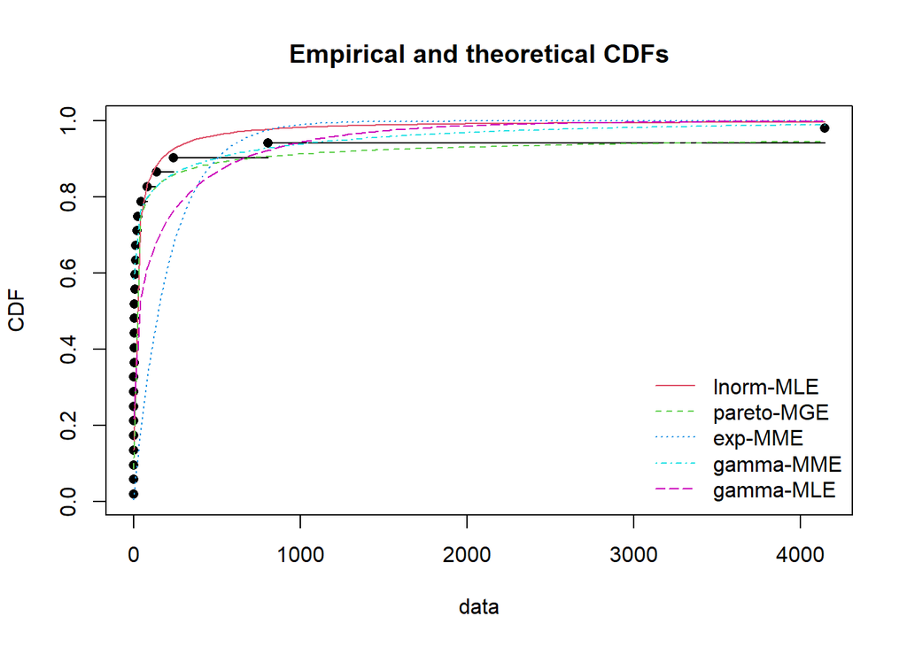

```r
# Graficar ajustes
# x11()
cdfcomp(list(dislogn, fitpareto, fitexp, iniciales_gamma, fitgamma))
```

```r
# Lista de los ajustes
modelos <- list(dislogn, fitpareto, fitexp, iniciales_gamma, fitgamma)

# Extraer loglik, aic y bic de cada modelo
loglikfit <- sapply(modelos, function(x) x$loglik)
aicfit <- sapply(modelos, function(x) x$aic)
bicfit <- sapply(modelos, function(x) x$bic)

# Combinamos en una matriz
salida <- rbind(loglikfit, aicfit, bicfit)

# Asignar nombres a las columnas y filas
colnames(salida) <- c("LogN", "Pareto", "Exponencial", "Gamma MME", "Gamma MLE")
rownames(salida) <- c("Loglik", "AIC", "BIC")
salida
```

```
##             LogN    Pareto Exponencial Gamma MME Gamma MLE
## Loglik -117.8459 -112.2783   -165.6505 -141.0396 -129.7298
## AIC     239.6918  228.5567    333.3011  286.0792  263.4595
## BIC     242.2080  231.0728    334.5592  288.5954  265.9757
```

## 4.8 Indice Criminalidad

```r
# Tabla de indice de criminalidad
indice_criminalidad <- df_deaths %>%
  mutate(df_deaths, total_muertes_1 = deaths_a + deaths_b+deaths_civilians + deaths_unknown) %>%
  group_by(year, adm_1) %>%
  filter( year > 2002, year < 2023) %>%
  summarise(muertes_tot = sum(total_muertes_1, na.rm = TRUE), .groups = "drop")

# Normalización por población
# 1. Primero se necesita importar la base de datos de población por estado (obtenida en INEGI)
base_poblacion <- readxl::read_excel("datos/poblacion_INEGI.xlsx")

# 2. Convertir la base en tidy
pob_tidy <- base_poblacion %>%
  pivot_longer(cols = c('2000','2005','2010','2020'),
               names_to = "año",
               values_to = "poblacion") %>%
  mutate(año= as.integer(año))

# 3. Interpolacion

pob_completa <- pob_tidy %>%
  group_by(Estado) %>%
  complete(año = 2000:2023) %>%
  arrange(Estado, año) %>%
  mutate(poblacion_interpolada = approx(x  = año[!is.na(poblacion)],
                                   y = poblacion[!is.na(poblacion)],
                                   xout = año,
                                   method = "linear",
                                   rule= 2)$y) %>%
  ungroup()


# Cambiar nombre de estados en indice_criminalidad

indice_criminalidad <- indice_criminalidad %>%
  rename(estado= adm_1 ,año= year)

pob_completa <- pob_completa %>%
  rename(estado = Estado)

# Modificar tipo de dato de año y estado del indice de criminalidad y población
#str(indice_criminalidad)
#str(pob_completa)
indice_criminalidad$año <- as.integer(indice_criminalidad$año)
indice_criminalidad$estado <- as.character(indice_criminalidad$estado)
pob_completa$año <- as.integer(pob_completa$año)
pob_completa$estado <- as.character(pob_completa$estado)

# Unir la información de población total y la de muertes

indice_criminalidad <- indice_criminalidad %>%
  left_join(pob_completa %>% dplyr::select(estado, año, poblacion_interpolada), by = c("estado", "año"))

# Haciendo la normalización para el indice de criminalidad cada 100,000 habitantes
indice_criminalidad <- indice_criminalidad %>%
  mutate(indice_crim = (muertes_tot / poblacion_interpolada) * 100000)
```

```r
data_aguacate <- df_aguacate %>%
    dplyr::select(Anio,Nomestado, Volumenproduccion, Precio, Valorproduccion, perdida_siembra_cosecha, indice_perdida_cys)

# Sumando cada uno de filas por año y estado, para tener un solo valor
data_aguacate <- data_aguacate %>%
  group_by(Anio, Nomestado) %>%
  summarise(across(
    .cols = c(Volumenproduccion, Precio, Valorproduccion, perdida_siembra_cosecha, indice_perdida_cys),
    .fns = ~ sum(.x, na.rm = TRUE)
  ), .groups = "drop")

# Cambiando los nombres de las columnas Anio y Nomestado de data_aguacate para que coincida en la busqueda con la tabla indice_criminalidad

data_aguacate <- data_aguacate %>%
  rename(estado= Nomestado ,año= Anio)

# Unir las columnas de data_aguacate con indice_criminalidad
indice_criminalidad <- indice_criminalidad %>%
  left_join(data_aguacate %>%
  dplyr::select(estado, año, perdida_siembra_cosecha, Precio, Valorproduccion, Volumenproduccion, indice_perdida_cys), by = c("estado", "año"))

# Cambio de variable categorica para los estados
library(fastDummies)
dummy_cols(indice_criminalidad, select_columns = "estado")
```

```
## # A tibble: 346 × 42
##      año estado           muertes_tot poblacion_interpolada indice_crim
##    <dbl> <chr>                  <dbl>                 <dbl>       <dbl>
##  1  2004 Chiapas                    3              4218946.     0.0711
##  2  2004 Chihuahua                 51              3203737.     1.59
##  3  2004 Ciudad de Mexico           1              8697781.     0.0115
##  4  2004 Guerrero                   8              3108091.     0.257
##  5  2004 Mexico                     1             13825333.     0.00723
##  6  2004 Nuevo Leon                 1              4126262.     0.0242
##  7  2004 Quintana Roo               5              1083240.     0.462
##  8  2004 Sinaloa                   55              2594122.     2.12
##  9  2004 Sonora                     4              2359283.     0.170
## 10  2004 Tamaulipas                88              2970035.     2.96
## # ℹ 336 more rows
## # ℹ 37 more variables: perdida_siembra_cosecha <dbl>, Precio <dbl>,
## #   Valorproduccion <dbl>, Volumenproduccion <dbl>, indice_perdida_cys <dbl>,
## #   estado_Aguascalientes <int>, `estado_Baja California` <int>,
## #   `estado_Baja California Sur` <int>, estado_Chiapas <int>,
## #   estado_Chihuahua <int>, `estado_Ciudad de Mexico` <int>,
## #   estado_Coahuila <int>, estado_Colima <int>, estado_Durango <int>, …
```

# 5. Metodologia

La metodologia empleada en este estudio se basa en un enfoque cuantitativo y un diseño de investigación descriptivo. Esto se debe a la utilización de variables concretas, datos numéricos e información estadistica con el propósito de realizar un análisis detallado sobre el cultivo de aguacate en México durante el periodo 2003-2022.

Para el diseño del seguro dirigido a los productores de aguacate, se calculó la prima pura de riesgo mediante un modelo lineal generalizado.

El análisis se sustentó en dos fuentes principales de datos. Por un lado, la información sobre la producción de aguacate proviene del Sistema de Información Agroalimentaria y Pesquera (SIAP) de la Secretaria de Agricultura, Ganaderia, Desarrollo Rural, Pesca y Alimentación (SAGARPA). Por otro lado, los datos sobre violencia en México fueron extraidos de la base de datos de la Universidad de Uppsala, la cual proporciona información detallada sobre los distintos niveles y caracteristicas de los eventos violentos. Ambas bases de datos abarcan el periodo comprendido entre 2003 y 2022.

Para el tratamiento de los datos, se llevó a cabo un proceso de depuración utilizando Excel y el software R, con el objetivo de conservar únicamente la información relevante. En el caso de la base de datos de producción de aguacate, se incluyeron variables como superficie sembrada, cosechada, siniestrada y volumen de producción (expresado en toneladas por hectárea) y precios en pesos mexicanos. En cuanto a la base de datos sobre violencia, se consideraron las muertes totales derivadas de enfrentamientos entre grupos criminales, el gobierno y civiles.

# 6. Modelo

- Reducción de Dimensinalidad

Facilitar el análisis de múltiples factores de crimen organizado que afectan a la producción de los productores de aguacate,tras haber complementado con la información necesaria de estorsiones, derechos de piso, desapariciones, entre otros.

- Segmetación de Datos

Reconocer la influencia que tienen los factores de violencia sobre las pérdidas en la producción, para delimitar zonas de riesgo y ajustar el valor de la prima con valores de sobre cargo dependiendo ubicación de la producción. Dicha clusterización se deja para el sigueinte parcial pues como se comenta en la sección 4.5. hay autores que en estudios previos resaltan que la presencia de desaparición de personas también es un indicador importante de presencia y presión de crimen organizado, entre otros factores, por lo que es necesario complementar la información.

- Modelo Lineal Generalizado

- Análisis de Estrés de la Prima Pura de Riesgo

Generar escenarios adversos y extremos se somete a estrés la metodologia usada para el cálculo de la PPR y verificando asi la propia capacidad del modelo de adaptarse a casos extremos cubietos por la póliza.

## 6.1 Ajuste a Modelo GLM

Se ajustó un modelo lineal generalizado (GLM) con distribución Gamma y función de enlace logarítmica, con el fin de predecir las pérdidas de producto sembrado y cosechado en la produccion de aguacate, con base en variables socioeconómicas y agroproductivas tales como:

- índice de criminalidad (por cada 100,000 habitantes)
- Volumen de producción (en toneladas)
- Precio
- Valor de producción

Obteniendo asi:

```r
min_perdida <- min(na.omit(indice_criminalidad$perdida_siembra_cosecha))

mod_perdida_pareto2 <- vglm(perdida_siembra_cosecha ~ indice_crim + Volumenproduccion,
                   data = indice_criminalidad,
                   paretoII(location = min_perdida - 1))

summary(mod_perdida_pareto2)
```

```
##
## Call:
## vglm(formula = perdida_siembra_cosecha ~ indice_crim + Volumenproduccion,
##     family = paretoII(location = min_perdida - 1), data = indice_criminalidad)
##
## Coefficients:
##                          Estimate    Std. Error z value             Pr(>|z|)
## (Intercept):1        1.0674001654  0.2477441160   4.308            0.0000164
## (Intercept):2       -1.1661945086  0.0985038306 -11.839 < 0.0000000000000002
## indice_crim:1        0.0355070849  0.0120855020   2.938              0.00330
## indice_crim:2        0.0208490292  0.0069137394   3.016              0.00256
## Volumenproduccion:1  0.0000050896  0.0000006010   8.469 < 0.0000000000000002
## Volumenproduccion:2  0.0000005682  0.0000003454   1.645              0.09998
##
## (Intercept):1       ***
## (Intercept):2       ***
## indice_crim:1       **
## indice_crim:2       **
## Volumenproduccion:1 ***
## Volumenproduccion:2 .
## ---
## Signif. codes:  0 '***' 0.001 '**' 0.01 '*' 0.05 '.' 0.1 ' ' 1
##
## Names of linear predictors: loglink(scale), loglink(shape)
##
## Log-likelihood: -1823.054 on 564 degrees of freedom
##
## Number of Fisher scoring iterations: 13
##
## No Hauck-Donner effect found in any of the estimates
```

```r
mean(residuals(mod_perdida_pareto2, type = "working"))
```

```
## [1] -0.000438226
```

```r
residuals(mod_perdida_pareto2, type = "deviance")
```

[output not shown]

```r
indice_criminalidad$perdida_siembra_cosecha_2 = replace(indice_criminalidad$perdida_siembra_cosecha, indice_criminalidad$perdida_siembra_cosecha == 0, NA)

mod_perdida_gamma <- glm(
  formula = perdida_siembra_cosecha_2 ~ indice_crim + Volumenproduccion + Precio + Valorproduccion,
  family = Gamma(link = "log"),
  data = indice_criminalidad
)

summary(mod_perdida_gamma)
```

```
##
## Call:
## glm(formula = perdida_siembra_cosecha_2 ~ indice_crim + Volumenproduccion +
##     Precio + Valorproduccion, family = Gamma(link = "log"), data = indice_criminalidad)
##
## Coefficients:
##                           Estimate       Std. Error t value
## (Intercept)        4.9997270728199  0.1259283401227  39.703
## indice_crim       -0.0175782626845  0.0051439265886  -3.417
## Volumenproduccion  0.0000049323153  0.0000009035761   5.459
## Precio             0.0000026104944  0.0000001740213  15.001
## Valorproduccion   -0.0000000002365  0.0000000000486  -4.867
##                               Pr(>|t|)
## (Intercept)       < 0.0000000000000002 ***
## indice_crim                   0.000756 ***
## Volumenproduccion          0.000000131 ***
## Precio            < 0.0000000000000002 ***
## Valorproduccion            0.000002186 ***
## ---
## Signif. codes:  0 '***' 0.001 '**' 0.01 '*' 0.05 '.' 0.1 ' ' 1
##
## (Dispersion parameter for Gamma family taken to be 1.734177)
##
##     Null deviance: 906.27  on 220  degrees of freedom
## Residual deviance: 414.54  on 216  degrees of freedom
##   (125 observations deleted due to missingness)
## AIC: 3071.4
##
## Number of Fisher Scoring iterations: 17
```

## 6.2 Pruebas Estadísticas de Comprobación del Modelo

> **Significancia estadística de los predictores**

```r
# Resumen del modelo
summary(mod_perdida_gamma)
```

```
##
## Call:
## glm(formula = perdida_siembra_cosecha_2 ~ indice_crim + Volumenproduccion +
##     Precio + Valorproduccion, family = Gamma(link = "log"), data = indice_criminalidad)
##
## Coefficients:
##                           Estimate       Std. Error t value
## (Intercept)        4.9997270728199  0.1259283401227  39.703
## indice_crim       -0.0175782626845  0.0051439265886  -3.417
## Volumenproduccion  0.0000049323153  0.0000009035761   5.459
## Precio             0.0000026104944  0.0000001740213  15.001
## Valorproduccion   -0.0000000002365  0.0000000000486  -4.867
##                               Pr(>|t|)
## (Intercept)       < 0.0000000000000002 ***
## indice_crim                   0.000756 ***
## Volumenproduccion          0.000000131 ***
## Precio            < 0.0000000000000002 ***
## Valorproduccion            0.000002186 ***
## ---
## Signif. codes:  0 '***' 0.001 '**' 0.01 '*' 0.05 '.' 0.1 ' ' 1
##
## (Dispersion parameter for Gamma family taken to be 1.734177)
##
##     Null deviance: 906.27  on 220  degrees of freedom
## Residual deviance: 414.54  on 216  degrees of freedom
##   (125 observations deleted due to missingness)
## AIC: 3071.4
##
## Number of Fisher Scoring iterations: 17
```

Sea el modelo:

$$\log(\mu_i) = \beta_0 + \beta_1\,\text{índice_crim}_i +
\beta_2\,\text{volumenproduccion}_i + \beta_3\,\text{Precio}_i +
\beta_4\,\text{Valorproduccion}_i$$

Las hipótesis a contrastar para cada coeficiente $\beta_j$ son:

Para cada predictor $j = 1, 2, 3, 4$:

$$\begin{aligned}
H_0\!:&\quad \beta_j = 0 \quad \text{(el predictor no tiene efecto)}
\\
H_1\!:&\quad \beta_j \neq 0 \quad \text{(el predictor tiene efecto
significativo)}
\end{aligned}$$
Dado que para todos los predictores considerados en el modelo se obtuvo un $p-value < 0.05$, se rechaza la hipótesis nula $H_0$ en cada caso, aceptando la existencia de una relación estadísticamente significativa entre los predictores y la respuesta.

Por tanto, se confirma con nivel de confianza del 95%, que cada una de las variables incluidas tiene un efecto significativo sobre la media esperada de las pérdidas.

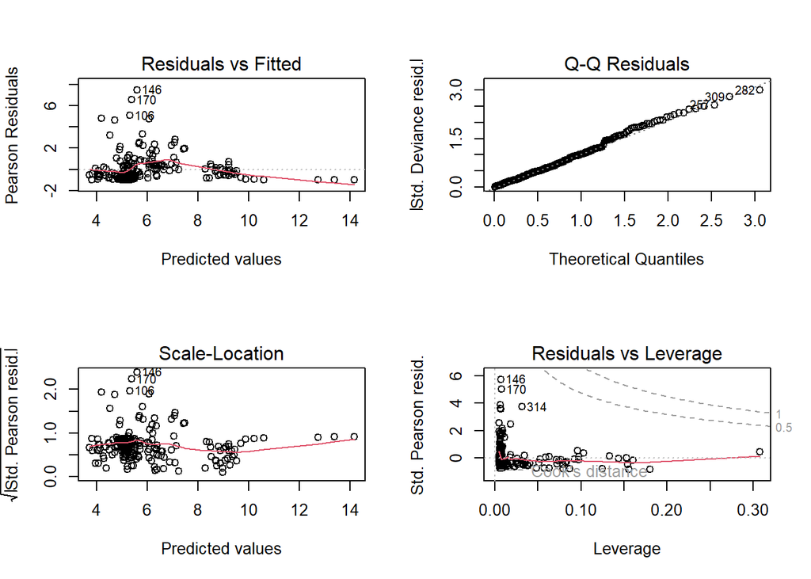

```r
# -Gráfica
# Establece un layout para mostrar 4 gráficos
par(mfrow = c(2, 2))

# Llama a los diagnósticos gráficos
plot(mod_perdida_gamma)
```

```r
# Volver a la configuración original
par(mfrow = c(1, 1))
```

Obteniendo la media y desviación estándar de los residuos:

```r
# Media y desviación de residuos
cat("Media de residuales: ", mean(residuals(mod_perdida_gamma)))
```

```
## Media de residuales:  -0.5267214
```

```r
cat("Vector de desviación de residuales: ", residuals(mod_perdida_gamma, type = "deviance"))
```

[output not shown]

```r
cat("Desviación de residuales: ", sd(residuals(mod_perdida_gamma)))
```

```
## Desviación de residuales:  1.267112
```

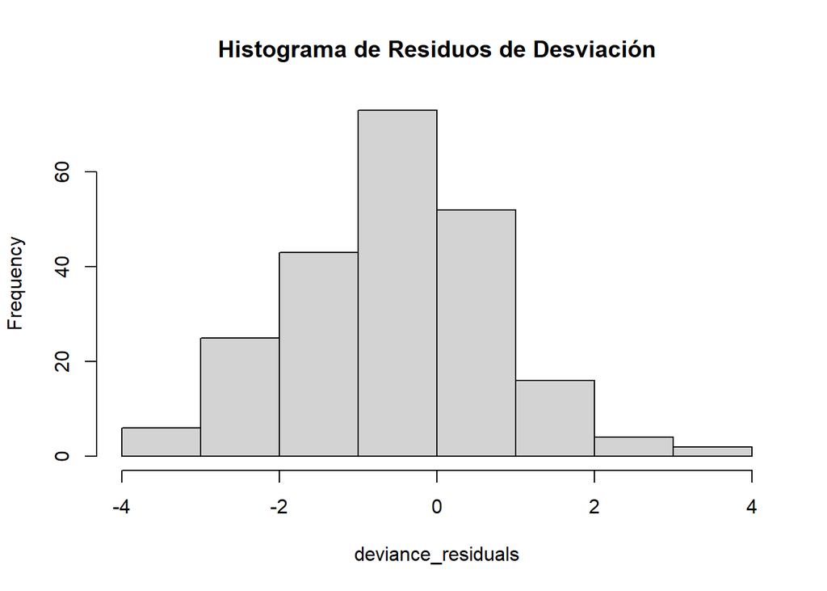

```r
# Gráfica de los residuos de desviación
deviance_residuals <- residuals(mod_perdida_gamma, type = "deviance")
hist(deviance_residuals, main = "Histograma de Residuos de Desviación")
```

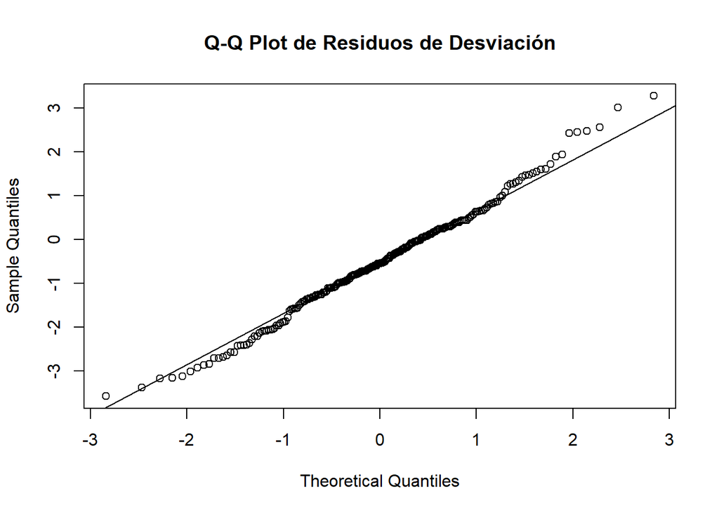

```r
qqnorm(deviance_residuals, main = "Q-Q Plot de Residuos de Desviación")
qqline(deviance_residuals)
```

```r
cat("AIC del modelo:", AIC(mod_perdida_gamma), "\n")
```

```
## AIC del modelo: 3071.418
```

```r
cat("BIC del modelo:", BIC(mod_perdida_gamma), "\n")
```

```
## BIC del modelo: 3091.807
```

Al realizar la evaluación comparativa y predictiva del modelo:

```r
pred <- predict(mod_perdida_gamma, type = "response")
obs  <- indice_criminalidad$perdida_siembra_cosecha_2

valido <- !is.na(obs)
pred <- pred[valido]
obs  <- obs[valido]

length(pred)
```

```
## [1] 221
```

```r
length(obs)
```

```
## [1] 221
```

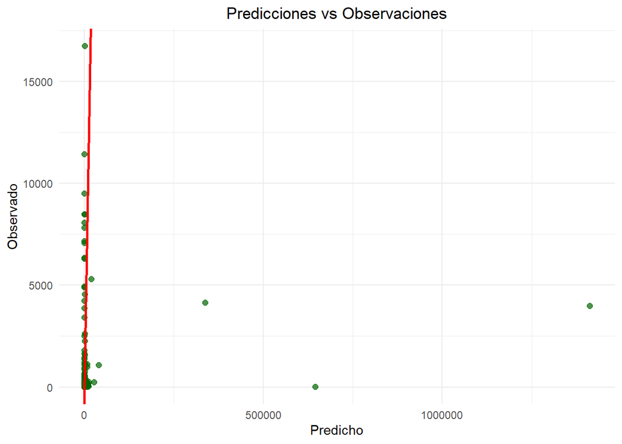

```r
library(ggplot2)

# Creamos un data frame con los valores válidos
df_plot <- data.frame(
  Observado = obs,
  Predicho  = pred
)

ggplot(df_plot, aes(x = Predicho, y = Observado)) +
  geom_point(color = "darkgreen", size = 2, alpha = 0.7) +
  geom_abline(intercept = 0, slope = 1, color = "red", linetype = "solid", size = 1) +
  labs(
    title = "Predicciones vs Observaciones",
    x = "Predicho",
    y = "Observado",
  ) +
  theme_minimal() +
  theme(plot.title = element_text(hjust = 0.5))
```

#### 6.2.1 Pruebas

> **1. Linealidad en parámetros**

Este supuesto implica que la relación entre los predictores y la expectativa transformada de la variable de respuesta, mediada por la función de enlace, es lineal. Este suspuesto se comprobará a través de los **gráficos de residuos parciales.**

Estos gráficos permiten verificar si la relación entre cada predictor y la variable de respuesta es realmente lineal.

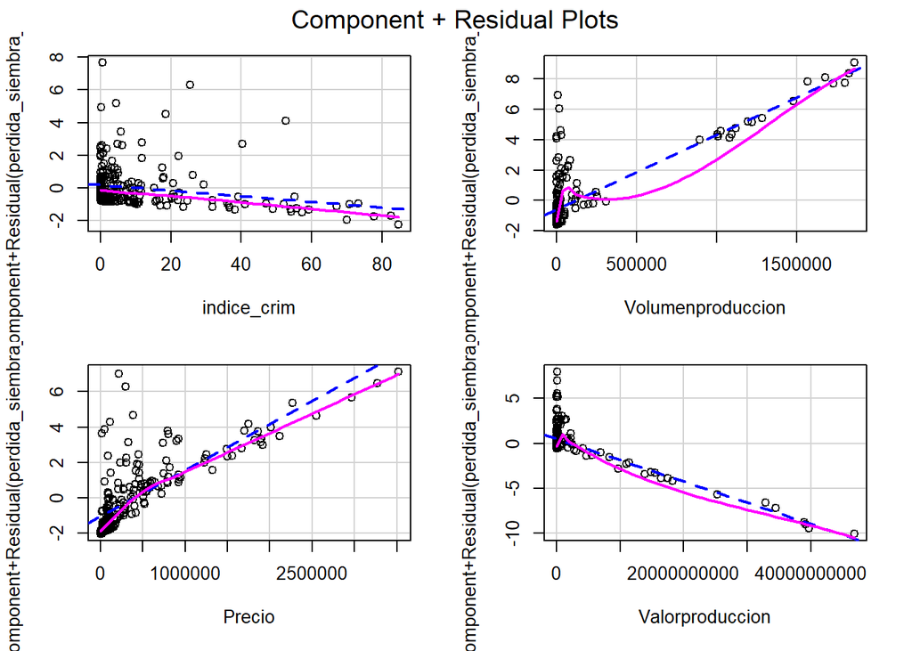

```r
crPlots(mod_perdida_gamma)
```

Como se puede observar, se realizó un gráfico por cada uno de los predictores: índice de criminalidad, Volumen de producción, precio y valor de producción, respectivamente.

Por otro lado, en el eje vertical se observan los residuos parciales (componente + residuo), que muestran el efecto “puro” del predictor sobre la respuesta.

La línea rosa hace referencia a la regresión local que indica la tendencia real de los datos, mientras que la línea azul punteada indica la referencia lineal según el modelo.

> **2. Independencia**

Dicho supuesto establece que la respuesta de cada observación debe ser independiente de las demás. Esta independencia es fundamental para la confiabilidad de la inferencia estadística dentro de los GLM, ya que la dependencia entre observaciones puede comprometer significativamente las conclusiones estadísticas del modelo al conducir a errores estándar subestimados.

Para corroborar esto, se sometió a la prueba **Durbin Watson**, la cuál evalúa la autocorrelación en los residuos cuando se tienen datos ordenados temporalmente. En este caso, debido a que los datos están ordenados desde 2003 a 2022, esta prueba es de utilidad.

Sean las hipótesis:
$$H_0: \rho = 0 \\
H_1: \rho > 0$$

```r
# Durbin Watson para no autocorrelación
dwtest(mod_perdida_gamma)
```

```
##
##  Durbin-Watson test
##
## data:  mod_perdida_gamma
## DW = 1.6682, p-value = 0.006336
## alternative hypothesis: true autocorrelation is greater than 0
```

> **3. Multicolinealidad**

La multicolinealidad ocurre cuando las variables predictivas están altamente correlacionadas, lo que puede distorsionar la estimación de los coeficientes de regresión

Si existe multicolinealidad, se podría indicar la necesidad de implementar métodos de regularización o selección de variables para garantizar la estabilidad del modelo.

El **factor de inflación de la varianza (VIF)** es una gran herramienta para detectar la multicolinealidad, ya que ofrece información que va más allá de las simples correlaciones por pares.

El VIF funciona cuantificando cuánto se infla la varianza de un coeficiente de regresión debido a las correlaciones entre los predictores. Estas correlaciones dificultan el aislamiento del efecto único de cada predictor sobre la variable objetivo, lo que conduce a estimaciones del modelo menos fiables. (Singh, 2024)

```r
vif(mod_perdida_gamma)
```

```
##       indice_crim Volumenproduccion            Precio   Valorproduccion
##          1.047696         13.984681          1.388539         14.850806
```

> **4. Homocedasticidad**

Este supuesto considera que la varianza es constante en los diferentes niveles de un factor, es decir, entre diferentes grupos. (Amat, 2016)

Para ello, se utilizará la prueba **Breusch-Pagan**, que consiste en ajustar un modelo de regresión lineal con variable respuesta dada por residuales del modelo original al cuadrado y como covariables las variables del modelo original. (Hernández, Usuga & Mazo, 2024)

Sean las hipótesis:
$$H_0: \mu = \mu_0 \\
H_1: \mu \neq \mu_0$$

```r
bptest(mod_perdida_gamma)
```

```
##
##  studentized Breusch-Pagan test
##
## data:  mod_perdida_gamma
## BP = 75.063, df = 4, p-value = 0.000000000000001932
```

## 6.3 Generacion Datos Sintéticos

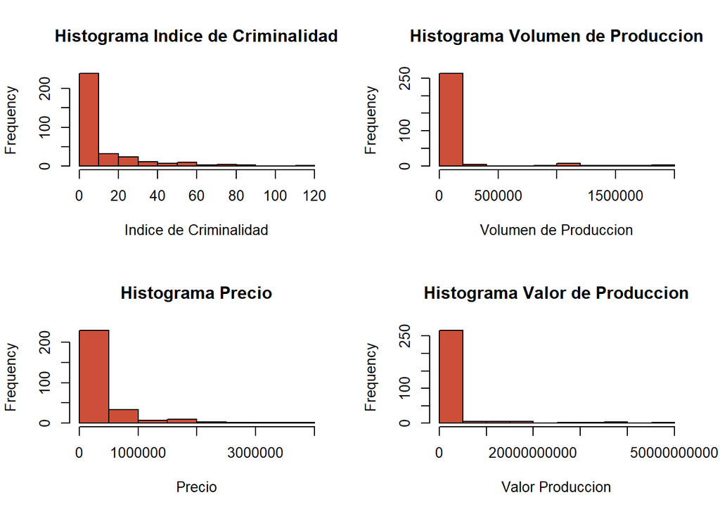

```r
par(mfrow = c(2, 2))

hist(indice_criminalidad$indice_crim, main = "Histograma Indice de Criminalidad", col = "tomato3", xlab = "Indice de Criminalidad")
hist(indice_criminalidad$Volumenproduccion, main = "Histograma Volumen de Produccion", col = "tomato3", xlab = "Volumen de Produccion")
hist(indice_criminalidad$Precio,main = "Histograma Precio", col = "tomato3", xlab = "Precio")
hist(indice_criminalidad$Valorproduccion,  main = "Histograma Valor de Produccion", col = "tomato3", xlab = "Valor Produccion")
```

```r
par(mfrow = c(1, 1))
```

```r
# Definir funcion para los números pesudo aleatorios del Generador Congruencial Lineal
funcion_gcl <- function(s, a, b, d, m){
  r <- numeric(m)
  r[1] <- s
  for (i in 1:(m-1)) {
    r[i+1] <- (a * r[i] + b) %% d
  }
  # Normalizando valores entre 0 y 1
  r <- (r+0.5) / d
  return(r)
  }
```

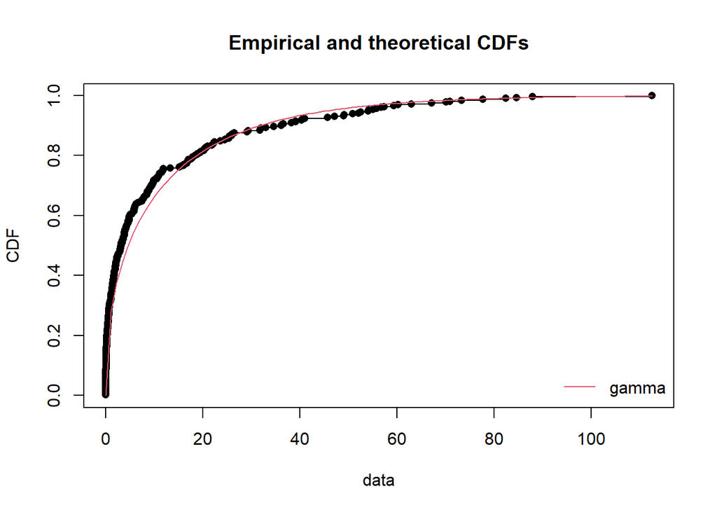

```r
# Parametros de la distribucion
new_datos <- indice_criminalidad$indice_crim[!is.na(indice_criminalidad$indice_crim)]
fit_gamma_indcrim <-fitdist(new_datos,
                    distr = "gamma",
                    method = "mle")
est_shape_indcrim <- fit_gamma_indcrim$estimate[1]
est_rate_indcrim <- fit_gamma_indcrim$estimate[2]

cdfcomp(fit_gamma_indcrim)
```

```r
# Parametros de Generador Congruencial Lineal
semilla <- 8990
a <- 567
b <- 131
d <- 979
m <- 250

# Generar valores
num_aleat <- funcion_gcl(semilla, a, b, d, m)

# Valores
sintetic_indice_crim <- qgamma(num_aleat, shape = est_shape_indcrim, rate = est_rate_indcrim)
```

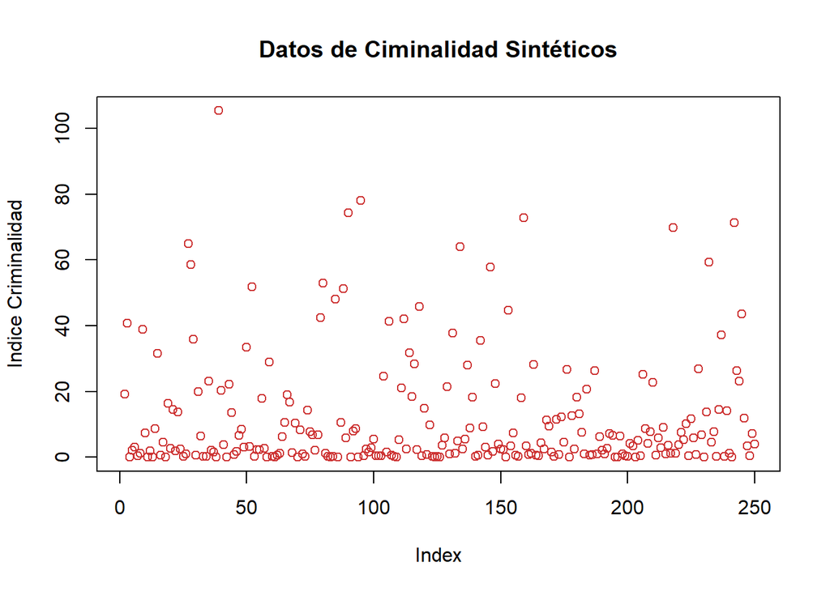

```r
plot(sintetic_indice_crim, col = "brown3", main = "Datos de Ciminalidad Sintéticos", ylab = "Indice Criminalidad")
```

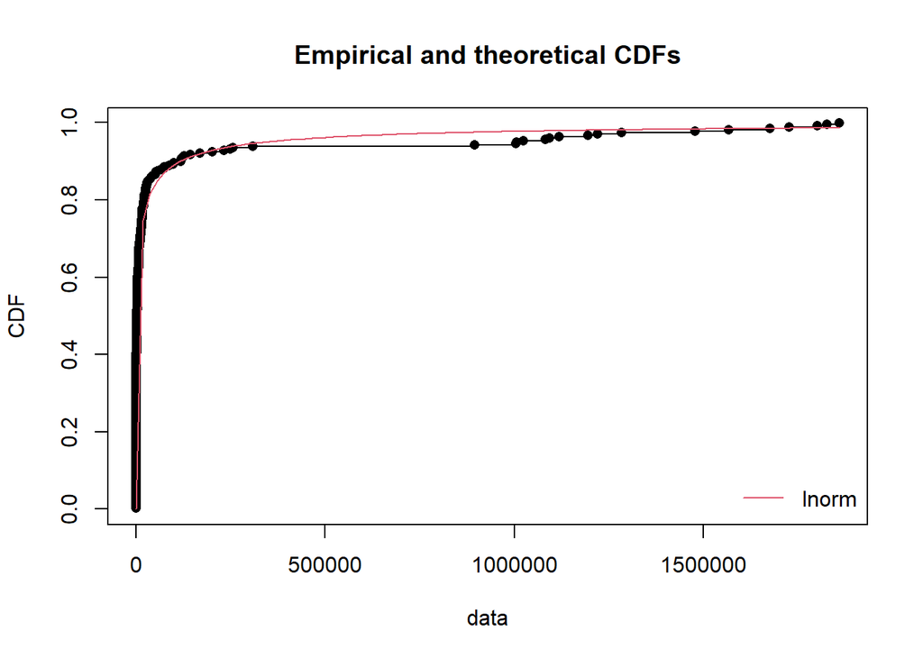

```r
# Parametros de la distribucion
new_datos <- indice_criminalidad$Volumenproduccion[!is.na(indice_criminalidad$Volumenproduccion)]
fit_lnorm_vol <-fitdist(new_datos + 0.01,
                    distr = "lnorm",
                    method = "mle")
est_mu_vol <- fit_lnorm_vol$estimate[1]
est_sd_vol <- fit_lnorm_vol$estimate[2]

cdfcomp(fit_lnorm_vol)
```

```r
# Parametros de Generador Congruencial Lineal
semilla <- 8990
a <- 567
b <- 131
d <- 979
m <- 250


# Generar valores
num_aleat <- funcion_gcl(semilla, a, b, d, m)

# Valores
sintetic_volumen <- qlnorm(num_aleat, meanlog = est_mu_vol, sdlog = est_sd_vol)
```

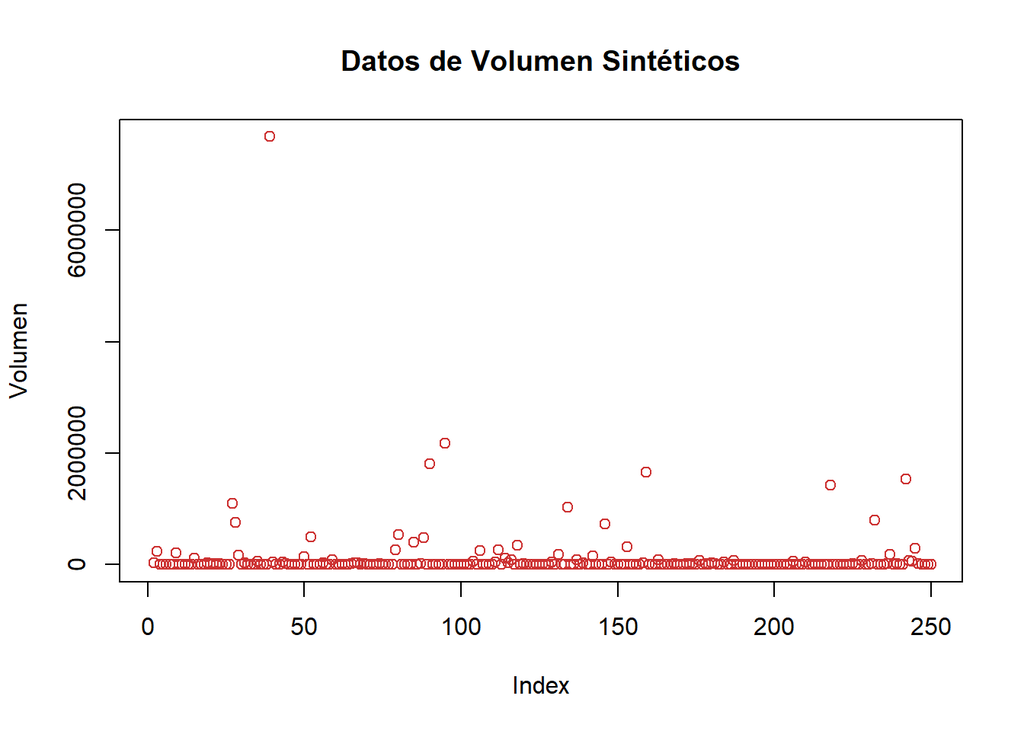

```r
plot(sintetic_volumen, col = "brown3", main = "Datos de Volumen Sintéticos", ylab = "Volumen")
```

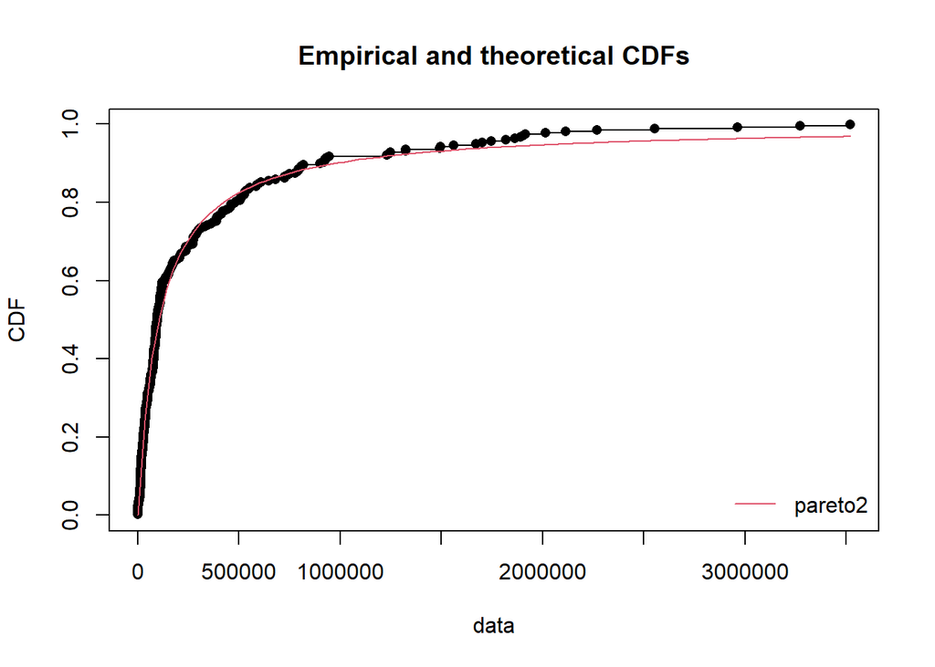

```r
# Parametros de la distribucion
new_datos <- indice_criminalidad$Precio[!is.na(indice_criminalidad$Precio)]
fit_pareto2_precio <-fitdist(new_datos,
                    distr = "pareto2",
                    method = "mge")
est_shape_precio <- fit_pareto2_precio$estimate[1]
est_rate_precio <- fit_pareto2_precio$estimate[2]

cdfcomp(fit_pareto2_precio)
```

```r
# Parametros de Generador Congruencial Lineal
semilla <- 8990
a <- 567
b <- 131
d <- 979
m <- 250


# Generar valores
num_aleat <- funcion_gcl(semilla, a, b, d, m)

# Valores
sintetic_precio <- qpareto2(num_aleat, min = min(num_aleat), shape = est_shape_precio, rate = est_rate_precio)
```

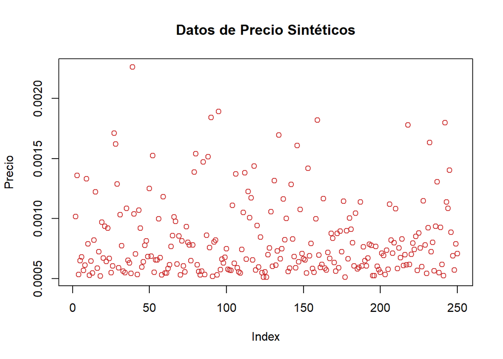

```r
plot(sintetic_precio, col = "brown3", main = "Datos de Precio Sintéticos", ylab = "Precio")
```

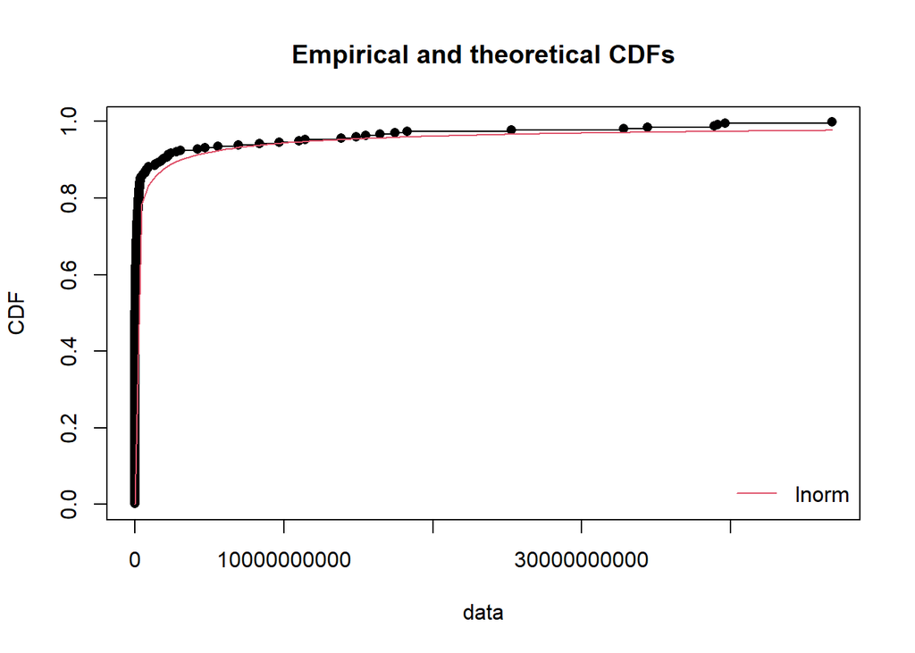

```r
# Parametros de la distribucion
new_datos <- indice_criminalidad$Valorproduccion[!is.na(indice_criminalidad$Valorproduccion)]
fit_lnorm_valor <-fitdist(new_datos + 0.01,
                    distr = "lnorm",
                    method = "mle")
est_mu_valor <- fit_lnorm_valor$estimate[1]
est_sd_valor <- fit_lnorm_valor$estimate[2]

cdfcomp(fit_lnorm_valor)
```

```r
# Parametros de Generador Congruencial Lineal
semilla <- 8990
a <- 567
b <- 131
d <- 979
m <- 250


# Generar valores
num_aleat <- funcion_gcl(semilla, a, b, d, m)

# Valores
sintetic_valor <- qlnorm(num_aleat, meanlog = est_mu_valor, sdlog = est_sd_valor)
```

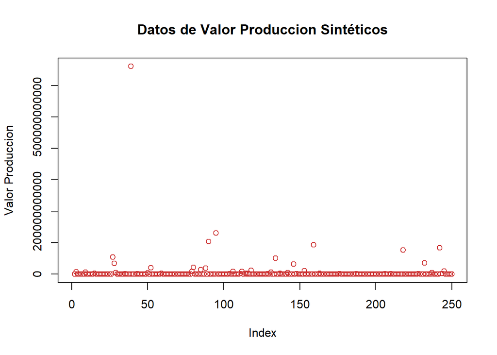

```r
plot(sintetic_valor, col = "brown3", main = "Datos de Valor Produccion Sintéticos", ylab = "Valor Produccion")
```

## 6.4 Validación con Datos Sintéticos

```r
# generar data frame
df_sinteticos <- data.frame(
  indice_crim = sintetic_indice_crim,
  Volumenproduccion = sintetic_volumen,
  Precio = sintetic_precio,
  Valorproduccion = sintetic_valor
)

# proyectamos usando el modelo estimado
df_sinteticos$perdida_proyectada <- predict.glm(mod_perdida_gamma,
                                                newdata = df_sinteticos,
                                                type = "response")

head(df_sinteticos, 20)
```

```
##     indice_crim Volumenproduccion       Precio Valorproduccion
## 1           NaN               NaN          NaN             NaN
## 2  19.110607081      33048.986853 0.0010175624    616695846.79
## 3  40.679461470     233666.460844 0.0013605878   7547724173.03
## 4   0.044257512         30.614427 0.0005325710        80515.03
## 5   2.042508319        882.442356 0.0006488656      5958919.24
## 6   2.993814044       1419.931330 0.0006800819     10957312.13
## 7   0.358387356        151.385131 0.0005686193       623414.98
## 8   1.090116240        437.582482 0.0006107199      2427053.01
## 9  38.811968882     203347.473607 0.0013325266   6317210068.54
## 10  7.282839643       5194.824826 0.0007898968     57682003.89
## 11  0.020607560         18.578405 0.0005261710        42472.10
## 12  1.987268865        854.164890 0.0006468920      5715505.49
## 13  0.115786143         60.763300 0.0005447175       193693.51
## 14  8.626936372       6910.583797 0.0008193093     83129688.81
```

[output cut: 27 more lines]

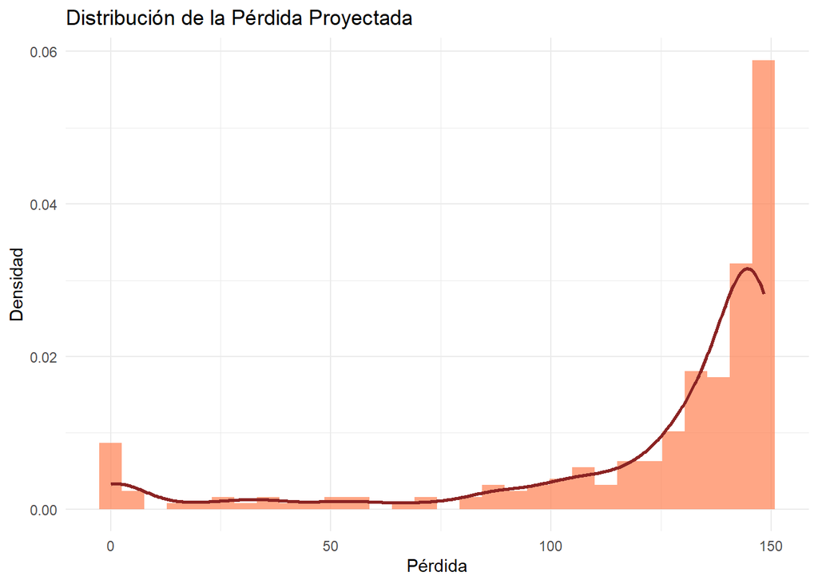

```r
#
ggplot(df_sinteticos, aes(x = perdida_proyectada)) +
  geom_histogram(aes(y = ..density..), bins = 30, fill = "coral", alpha = 0.7) +
  geom_density(color = "brown4", size = 1) +
  labs(title = "Distribución de la Pérdida Proyectada", x = "Pérdida", y = "Densidad") +
  theme_minimal()
```

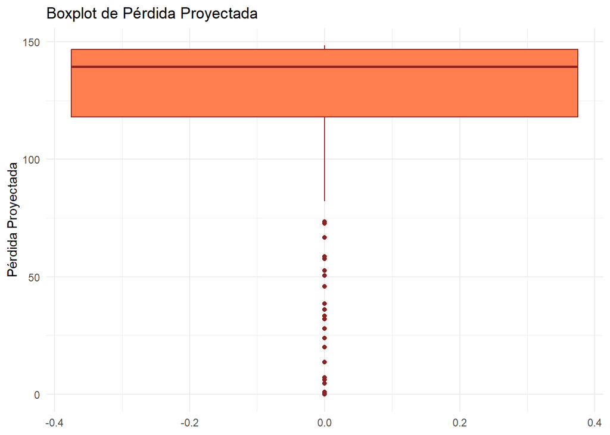

```r
#
ggplot(df_sinteticos, aes(y = perdida_proyectada)) +
  geom_boxplot(fill = "coral", color = "brown4") +
  labs(title = "Boxplot de Pérdida Proyectada", y = "Pérdida Proyectada") +
  theme_minimal()
```